# Label models

```python
from __future__ import annotations

from typing import Any

import matplotlib.pyplot as plt

from example_models import get_linear_chain_2v, get_tpi_ald_model
from mxlpy import (
    LabelMapper,
    LinearLabelMapper,
    Simulator,
    plot,
)


def print_annotated(description: str, value: Any) -> None:
    print(
        description,
        value,
        sep="\n",
        end="\n\n",
    )
```

## Labeled models

Labelled models allow explicitly mapping the transitions between isotopomers variables.  
This, for example, allows building models of the Calvin-Benson-Bassham cycle, in which each carbon atom can be labelled individually:

[figure not shown]

*mxlpy* includes a `LabelMapper` that takes

- a model
- a dictionary mapping the variables to the amount of label positions they have
- a transition map

to auto-generate all possible `2^n` variants of the variables and reaction transitions between them.

As an example let's take triose phosphate isomerase, which catalyzes the interconversion of glyceraldehyde 3-phosphate (GAP) and dihydroxyacetone phosphate (DHAP).  
As illustrated below, in the case of the forward reaction the first and last carbon atoms are swapped

[figure not shown]

So DHAP(1) is build from GAP(3), DHAP(2) from GAP(2) and DHAP(3) from GAP(1).  
We notate this using normal **0-based indexing** as follows

```
label_maps = {"TPIf": [2, 1, 0]}
```

```python
mapper = LabelMapper(
    get_tpi_ald_model(),
    label_variables={"GAP": 3, "DHAP": 3, "FBP": 6},
    label_maps={
        "TPIf": [2, 1, 0],
        "TPIr": [2, 1, 0],
        "ALDf": [0, 1, 2, 3, 4, 5],
        "ALDr": [0, 1, 2, 3, 4, 5],
    },
)


labels = (
    Simulator(mapper.build_model(initial_labels={"GAP": 0}))
    .simulate(20)
    .get_result()
    .unwrap_or_err()
).variables

fig, ax = plot.relative_label_distribution(mapper, labels, n_cols=3)
plt.show()
```

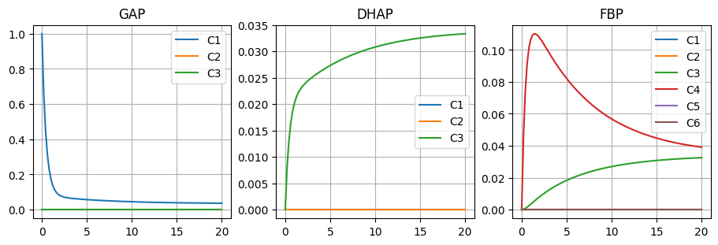

### Linear label mapper

The `LabelMapper` makes no assumptions about the state of the model, which causes a lot of complexity.  
In steady-state however, the space of possible solutions is reduced and the labelling dynamics can be represented by a set of linear differential equations.  
See [Sokol and Portais 2015](https://doi.org/10.1371/journal.pone.0144652) for the theory of dynamic label propagation under the stationary assumption.

```python
model_fn = get_tpi_ald_model()

concs, fluxes = Simulator(model_fn).simulate(20).get_result().unwrap_or_err()


mapper = LinearLabelMapper(
    model=model_fn,
    label_variables={"GAP": 3, "DHAP": 3, "FBP": 6},
    label_maps={
        "TPIf": [2, 1, 0],
        "TPIr": [2, 1, 0],
        "ALDf": [0, 1, 2, 3, 4, 5],
        "ALDr": [0, 1, 2, 3, 4, 5],
    },
)


labels = (
    Simulator(
        mapper.build_model(
            concs=concs.iloc[-1],
            fluxes=fluxes.iloc[-1],
            initial_labels={"GAP": 0},
        )
    )
    .simulate(20)
    .get_result()
    .unwrap_or_err()
).variables
fig, ax = plot.relative_label_distribution(mapper, labels, n_cols=3)
plt.show()
```

[figure not shown]

## First finish line

With that you now know most of what you will need from a day-to-day basis about labelled models in mxlpy.  
Congratulations!

## Advanced topics

### External & initial labels

In the case of open models, we make the assumption that there is a static pool of external labels.  
For example, this could be the labelled portion of ambient carbon dioxide.  
We denote that external label pool with `EXT` and by default set the value `1.0` to it, which means that it is fully labelled.

```python
model = get_linear_chain_2v()
concs, fluxes = Simulator(model).simulate(100).get_result().unwrap_or_err()
mapper = LinearLabelMapper(
    model,
    label_variables={"x": 2, "y": 2},
    label_maps={
        "v1": [0, 1],
        "v2": [0, 1],
        "v3": [0, 1],
    },
)

label_model = mapper.build_model(
    concs=concs.iloc[-1],
    fluxes=fluxes.iloc[-1],
)

# Access the external label pool
print(label_model.get_parameter_values()["EXT"])

# A reaction that consumes the external label pool
print(label_model.get_raw_reactions()["v1__0"].args)

# A reaction that doesn't require the external label pool
print(label_model.get_raw_reactions()["v2__0"].args)
```

```
1.0
['EXT', 'v1']
['x__0', 'v2']
```

You can modify the external concentration to your liking by simply updating the parameter value.

```python
fig, ax = plot.relative_label_distribution(
    mapper,
    (
        Simulator(label_model)
        .update_parameter("EXT", 1.0)  # update exeternal label to fully labelled
        .simulate(20)
        .get_result()
        .unwrap_or_err()
    ).variables,
    n_cols=3,
)
fig.suptitle("Fully labelled external pool")
plt.show()
```

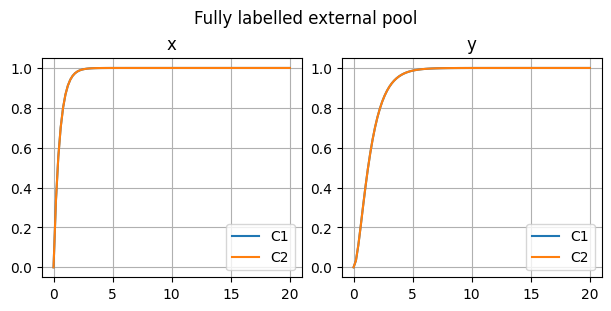

```python
fig, axs = plot.relative_label_distribution(
    mapper,
    (
        Simulator(label_model)
        .update_parameter("EXT", 0.5)  # update external label to half labelled
        .simulate(20)
        .get_result()
        .unwrap_or_err()
    ).variables,
    n_cols=3,
)
fig.suptitle("Half labelled external pool")
for ax in axs:
    ax.set_ylim(0, 1)
plt.show()
```

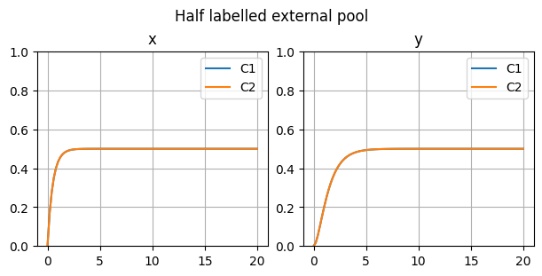

Somewhat trivially, if you have no external label, there is no influx of labels

```python
fig, axs = plot.relative_label_distribution(
    mapper,
    (
        Simulator(label_model)
        .update_parameter("EXT", 0.0)
        .simulate(20)
        .get_result()
        .unwrap_or_err()
    ).variables,
    n_cols=3,
)
fig.suptitle("No labelled external pool")
for ax in axs:
    ax.set_ylim(0, 1)
plt.show()
```

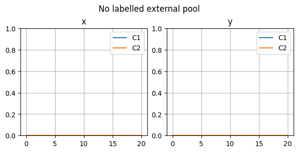

However, we can imagine a scenario where some initial labels are given, even though there is no external labeling.  
You can achieve that by updating the initial conditions like so.

```python
fig, axs = plot.relative_label_distribution(
    mapper,
    (
        Simulator(label_model, y0=label_model.get_initial_conditions() | {"x__0": 1.0})
        .update_parameter("EXT", 0.0)
        .simulate(20)
        .get_result()
        .unwrap_or_err()
    ).variables,
    n_cols=3,
)
fig.suptitle("No labelled external pool")
for ax in axs:
    ax.set_ylim(0, 1)
plt.show()
```

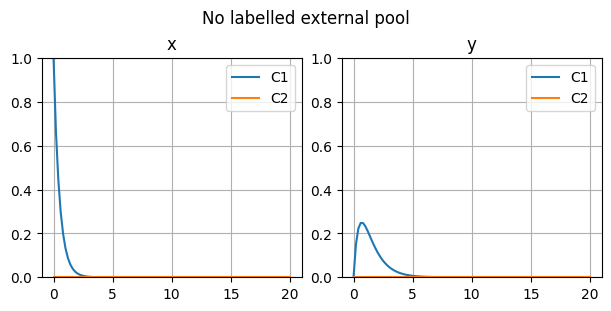

For convenience, the `build_model` function also allows you to set the external labels and the initial labels.  
Here, `initial_labels` specifies the position at which the initial label is given.

```python
label_model = mapper.build_model(
    concs=concs.iloc[-1],
    fluxes=fluxes.iloc[-1],
    external_label=0.0,
    initial_labels={"x": 0},
)

fig, axs = plot.relative_label_distribution(
    mapper,
    Simulator(label_model).simulate(20).get_result().unwrap_or_err().variables,
    n_cols=3,
)
fig.suptitle("No external label, but initial label in C1 of x")
plt.show()
```

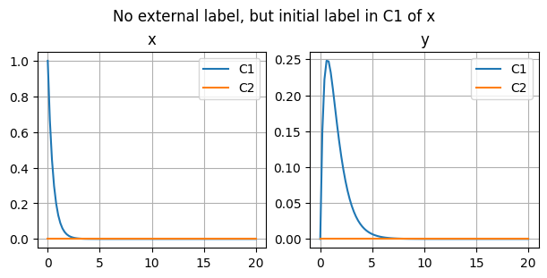

You can also distribute that initial label across multiple label positions of the variable.

```python
label_model = mapper.build_model(
    concs=concs.iloc[-1],
    fluxes=fluxes.iloc[-1],
    external_label=0.0,
    initial_labels={"x": [0, 1]},
)

fig, axs = plot.relative_label_distribution(
    mapper,
    Simulator(label_model).simulate(20).get_result().unwrap_or_err().variables,
    n_cols=3,
)
fig.suptitle("No external label, but initial label in C1 & C2 of x")
plt.show()
```

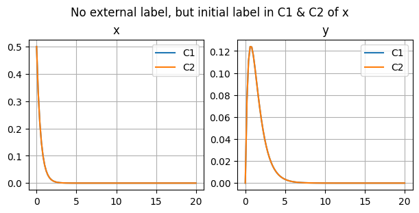